# Starbucks Capstone Challenge

### Project Overview

This data set contains simulated data that mimics customer behavior on the Starbucks rewards mobile app. Once every few days, Starbucks sends out an offer to users of the mobile app. An offer can be merely an advertisement for a drink or an actual offer such as a discount or BOGO (buy one get one free). Some users might not receive any offer during certain weeks.

Not all users receive the same offer, and that is the challenge to solve with this data set.

Your task is to combine transaction, demographic and offer data to determine which demographic groups respond best to which offer type. This data set is a simplified version of the real Starbucks app because the underlying simulator only has one product whereas Starbucks actually sells dozens of products.

Every offer has a validity period before the offer expires. As an example, a BOGO offer might be valid for only 5 days. You'll see in the data set that informational offers have a validity period even though these ads are merely providing information about a product; for example, if an informational offer has 7 days of validity, you can assume the customer is feeling the influence of the offer for 7 days after receiving the advertisement.

You'll be given transactional data showing user purchases made on the app including the timestamp of purchase and the amount of money spent on a purchase. This transactional data also has a record for each offer that a user receives as well as a record for when a user actually views the offer. There are also records for when a user completes an offer.

Keep in mind as well that someone using the app might make a purchase through the app without having received an offer or seen an offer.

### Problem Statement

We are trying to predict if the user will complete the offer or not based on the data presented

# Metrics

The data is contained in three files:

- portfolio.json - containing offer ids and meta data about each offer (duration, type, etc.)
- profile.json - demographic data for each customer
- transcript.json - records for transactions, offers received, offers viewed, and offers completed

Here is the schema and explanation of each variable in the files:

**portfolio.json**

- id (string) - offer id
- offer_type (string) - type of offer ie BOGO, discount, informational
- difficulty (int) - minimum required spend to complete an offer
- reward (int) - reward given for completing an offer
- duration (int) - time for offer to be open, in days
- channels (list of strings)

**profile.json**

- age (int) - age of the customer
- became_member_on (int) - date when customer created an app account
- gender (str) - gender of the customer (note some entries contain 'O' for other rather than M or F)
- id (str) - customer id
- income (float) - customer's income

**transcript.json**

- event (str) - record description (ie transaction, offer received, offer viewed, etc.)
- person (str) - customer id
- time (int) - time in hours since start of test. The data begins at time t=0
- value - (dict of strings) - either an offer id or transaction amount depending on the record

Finally, when you enter back into the notebook (use the jupyter icon again), you should be able to run the below cell without any errors.

### Analysis

```python
import pandas as pd
import numpy as np
import math
import json
import datetime
import matplotlib.pyplot as plt
import seaborn as sns
import pickle
%matplotlib inline

from time import time
from IPython.display import display # Allows the use of display() for DataFrames
```

```python
# read in the json files
portfolio = pd.read_json('portfolio.json', orient='records', lines=True)
profile = pd.read_json('profile.json', orient='records', lines=True)
transcript = pd.read_json('transcript.json', orient='records', lines=True)
```

# Portfolio dataset

```python
portfolio.head()
```

|  | reward | channels | difficulty | duration | offer_type | id |
| --- | --- | --- | --- | --- | --- | --- |
| 0 | 10 | [email, mobile, social] | 10 | 7 | bogo | ae264e3637204a6fb9bb56bc8210ddfd |
| 1 | 10 | [web, email, mobile, social] | 10 | 5 | bogo | 4d5c57ea9a6940dd891ad53e9dbe8da0 |
| 2 | 0 | [web, email, mobile] | 0 | 4 | informational | 3f207df678b143eea3cee63160fa8bed |
| 3 | 5 | [web, email, mobile] | 5 | 7 | bogo | 9b98b8c7a33c4b65b9aebfe6a799e6d9 |
| 4 | 5 | [web, email] | 20 | 10 | discount | 0b1e1539f2cc45b7b9fa7c272da2e1d7 |

```python
portfolio.info()
```

```
<class 'pandas.core.frame.DataFrame'>
RangeIndex: 10 entries, 0 to 9
Data columns (total 6 columns):
 #   Column      Non-Null Count  Dtype
---  ------      --------------  -----
 0   reward      10 non-null     int64
 1   channels    10 non-null     object
 2   difficulty  10 non-null     int64
 3   duration    10 non-null     int64
 4   offer_type  10 non-null     object
 5   id          10 non-null     object
dtypes: int64(3), object(3)
memory usage: 608.0+ bytes
```

```python
portfolio.describe()
```

|  | reward | difficulty | duration |
| --- | --- | --- | --- |
| count | 10.000000 | 10.000000 | 10.000000 |
| mean | 4.200000 | 7.700000 | 6.500000 |
| std | 3.583915 | 5.831905 | 2.321398 |
| min | 0.000000 | 0.000000 | 3.000000 |
| 25% | 2.000000 | 5.000000 | 5.000000 |
| 50% | 4.000000 | 8.500000 | 7.000000 |
| 75% | 5.000000 | 10.000000 | 7.000000 |
| max | 10.000000 | 20.000000 | 10.000000 |

```python
portfolio.shape
```

```
(10, 6)
```

```python
portfolio.isna().sum()
```

```
reward        0
channels      0
difficulty    0
duration      0
offer_type    0
id            0
dtype: int64
```

```python
portfolio['offer_type'].unique()
```

```
array(['bogo', 'informational', 'discount'], dtype=object)
```

```python
portfolio.columns.duplicated().sum()
```

```
0
```

```python
portfolio.groupby('offer_type')['id'].count()
```

```
offer_type
bogo             4
discount         4
informational    2
Name: id, dtype: int64
```

### Portfolio

```
- The data set has 6 columns and 10 rows
- The data set does not have any nulls or duplicates
- There are three typs of offer: BOGO, informational and discount
- The difficulty column is in dollar
```

# Profile dataset

```python
profile.head()
```

|  | gender | age | id | became_member_on | income |
| --- | --- | --- | --- | --- | --- |
| 0 | None | 118 | 68be06ca386d4c31939f3a4f0e3dd783 | 20170212 | NaN |
| 1 | F | 55 | 0610b486422d4921ae7d2bf64640c50b | 20170715 | 112000.0 |
| 2 | None | 118 | 38fe809add3b4fcf9315a9694bb96ff5 | 20180712 | NaN |
| 3 | F | 75 | 78afa995795e4d85b5d9ceeca43f5fef | 20170509 | 100000.0 |
| 4 | None | 118 | a03223e636434f42ac4c3df47e8bac43 | 20170804 | NaN |

```python
profile.shape
```

```
(17000, 5)
```

```python
profile.info()
```

```
<class 'pandas.core.frame.DataFrame'>
RangeIndex: 17000 entries, 0 to 16999
Data columns (total 5 columns):
 #   Column            Non-Null Count  Dtype
---  ------            --------------  -----
 0   gender            14825 non-null  object
 1   age               17000 non-null  int64
 2   id                17000 non-null  object
 3   became_member_on  17000 non-null  int64
 4   income            14825 non-null  float64
dtypes: float64(1), int64(2), object(2)
memory usage: 664.2+ KB
```

```python
profile.describe()
```

|  | age | became_member_on | income |
| --- | --- | --- | --- |
| count | 17000.000000 | 1.700000e+04 | 14825.000000 |
| mean | 62.531412 | 2.016703e+07 | 65404.991568 |
| std | 26.738580 | 1.167750e+04 | 21598.299410 |
| min | 18.000000 | 2.013073e+07 | 30000.000000 |
| 25% | 45.000000 | 2.016053e+07 | 49000.000000 |
| 50% | 58.000000 | 2.017080e+07 | 64000.000000 |
| 75% | 73.000000 | 2.017123e+07 | 80000.000000 |
| max | 118.000000 | 2.018073e+07 | 120000.000000 |

```python
profile.isna().sum()
```

```
gender              2175
age                    0
id                     0
became_member_on       0
income              2175
dtype: int64
```

```python
profile.columns.duplicated().sum()
```

```
0
```

```python
profile['id'].nunique()
```

```
17000
```

```python
portfolio.difficulty.unique()
```

```
array([10,  0,  5, 20,  7])
```

```python
profile['gender'].unique()
```

```
array([None, 'F', 'M', 'O'], dtype=object)
```

```python
profile[profile['age']==118].count()
```

```
gender                 0
age                 2175
id                  2175
became_member_on    2175
income                 0
dtype: int64
```

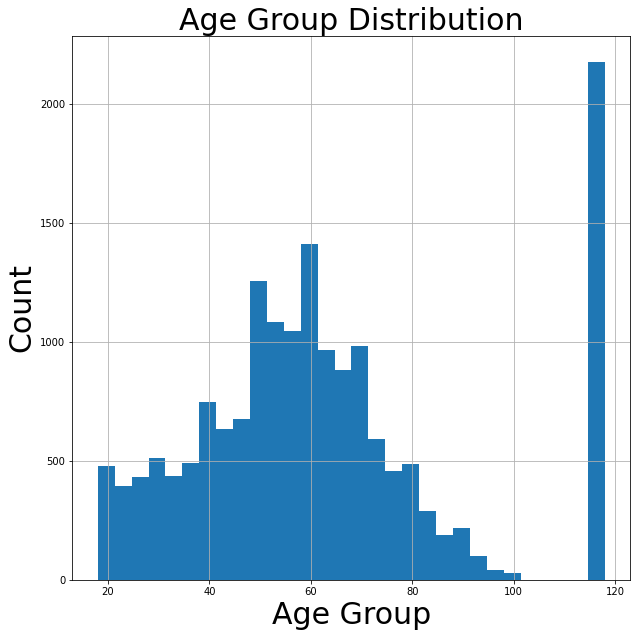

```python
plt.figure(figsize=(10,10))
profile.age.hist(bins = 30)
plt.xlabel('Age Group',size=30)
plt.ylabel('Count',size=30)
plt.title('Age Group Distribution',size=30);
```

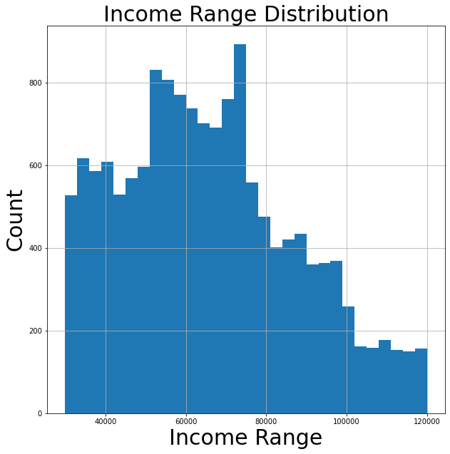

```python
plt.figure(figsize=(10,10))
profile.income.hist(bins = 30);
plt.xlabel('Income Range',size=30)
plt.ylabel('Count',size=30)
plt.title('Income Range Distribution',size=30);
```

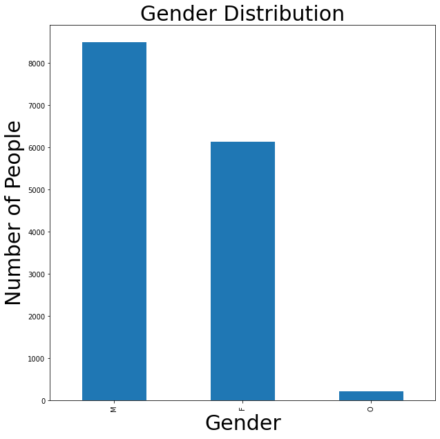

```python
plt.figure(figsize=(10,10))
ax = profile.gender.value_counts()
ax.plot(kind='bar')
plt.ylabel('Number of People',size=30)
plt.xlabel('Gender',size=30)
plt.title('Gender Distribution',size=30);
```

```python
profile.gender.value_counts()
```

```
M    8484
F    6129
O     212
Name: gender, dtype: int64
```

# Profile

[output not shown]

```python
transcript.head()
```

|  | person | event | value | time |
| --- | --- | --- | --- | --- |
| 0 | 78afa995795e4d85b5d9ceeca43f5fef | offer received | {'offer id': '9b98b8c7a33c4b65b9aebfe6a799e6d9'} | 0 |
| 1 | a03223e636434f42ac4c3df47e8bac43 | offer received | {'offer id': '0b1e1539f2cc45b7b9fa7c272da2e1d7'} | 0 |
| 2 | e2127556f4f64592b11af22de27a7932 | offer received | {'offer id': '2906b810c7d4411798c6938adc9daaa5'} | 0 |
| 3 | 8ec6ce2a7e7949b1bf142def7d0e0586 | offer received | {'offer id': 'fafdcd668e3743c1bb461111dcafc2a4'} | 0 |
| 4 | 68617ca6246f4fbc85e91a2a49552598 | offer received | {'offer id': '4d5c57ea9a6940dd891ad53e9dbe8da0'} | 0 |

```python
transcript.shape
```

```
(306534, 4)
```

```python
transcript.columns.duplicated().sum()
```

```
0
```

```python
transcript.isna().sum()
```

```
person    0
event     0
value     0
time      0
dtype: int64
```

```python
transcript.event.unique()
```

```
array(['offer received', 'offer viewed', 'transaction', 'offer completed'],
      dtype=object)
```

```python
transcript.info()
```

```
<class 'pandas.core.frame.DataFrame'>
RangeIndex: 306534 entries, 0 to 306533
Data columns (total 4 columns):
 #   Column  Non-Null Count   Dtype
---  ------  --------------   -----
 0   person  306534 non-null  object
 1   event   306534 non-null  object
 2   value   306534 non-null  object
 3   time    306534 non-null  int64
dtypes: int64(1), object(3)
memory usage: 9.4+ MB
```

```python
transcript.describe()
```

|  | time |
| --- | --- |
| count | 306534.000000 |
| mean | 366.382940 |
| std | 200.326314 |
| min | 0.000000 |
| 25% | 186.000000 |
| 50% | 408.000000 |
| 75% | 528.000000 |
| max | 714.000000 |

# Transcript

- it doesnot have any nulls or duplicating values
- there is 4 type of events
- The value column is a kind of dictionary, you will need to do extract data from it

# Data preprocessing

### portfolio wrangling and cleaning

- I turned the channel into categories in each column
- I turned the offer type into categories for each column
- I changed id column name to offer id
- I changed the duration to be in hours instead ofays.
- I changed the huge offer id into a short numbers to be easier to show

```python
new_editted_portfolio = portfolio.copy()
```

```python
dummy = pd.get_dummies(portfolio.channels.apply(pd.Series).stack()).sum(level=0)
new_editted_portfolio = pd.concat([new_editted_portfolio, dummy], axis=1)
new_editted_portfolio.drop(columns='channels',inplace = True)
```

```python
dummy = pd.get_dummies(portfolio.offer_type	.apply(pd.Series).stack()).sum(level=0)
new_editted_portfolio = pd.concat([new_editted_portfolio, dummy], axis=1)
```

```python
new_editted_portfolio.rename(columns={'id':'offer_id'},inplace = True)
```

```python
new_editted_portfolio['duration'] = new_editted_portfolio['duration']*24
```

```python
new_editted_portfolio.rename(columns={'duration':'duration_hours'},inplace = True)
```

```python
# replacing the 'offer_id' by more easy ids
labels_offer_id = new_editted_portfolio['offer_id'].astype('category').cat.categories.tolist()
replace_map_comp_offer_id = {'offer_id' : {k: v for k,v in zip(labels_offer_id,list(range(1,len(labels_offer_id)+1)))}}
new_editted_portfolio.replace(replace_map_comp_offer_id, inplace=True)
```

```python
labels_offer_type = new_editted_portfolio['offer_type'].astype('category').cat.categories.tolist()
replace_map_comp_offer_type = {'offer_type' : {k: v for k,v in zip(labels_offer_type,list(range(1,len(labels_offer_type)+1)))}}
new_editted_portfolio.replace(replace_map_comp_offer_type, inplace=True)
```

```python
new_editted_portfolio.head()
```

|  | reward | difficulty | duration_hours | offer_type | offer_id | email | mobile | social | web | bogo | discount | informational |
| --- | --- | --- | --- | --- | --- | --- | --- | --- | --- | --- | --- | --- |
| 0 | 10 | 10 | 168 | 1 | 8 | 1 | 1 | 1 | 0 | 1 | 0 | 0 |
| 1 | 10 | 10 | 120 | 1 | 5 | 1 | 1 | 1 | 1 | 1 | 0 | 0 |
| 2 | 0 | 0 | 96 | 3 | 4 | 1 | 1 | 0 | 1 | 0 | 0 | 1 |
| 3 | 5 | 5 | 168 | 1 | 7 | 1 | 1 | 0 | 1 | 1 | 0 | 0 |
| 4 | 5 | 20 | 240 | 2 | 1 | 1 | 0 | 0 | 1 | 0 | 1 | 0 |

### profile wrangling and cleaning

- I turned became member on into a date and subrated from it the number of days since being a member
- I made a simple categories for each customer id to be easier in using
- I removed all the data with age equal to 118
- I categorized gender into categories using numerical values to be used later in the machine learning model.
- I categorized age into categories with each category contain a range of ages. I used the categorized age using numerical values to be used later in the machine learning model.
- I categorized income into categories with each category contain a range of income. I used the categorized income using numerical values to be used later in the machine learning model.

```python
new_editted_profile = profile.copy()
```

```python
new_editted_profile.head()
```

|  | gender | age | id | became_member_on | income |
| --- | --- | --- | --- | --- | --- |
| 0 | None | 118 | 68be06ca386d4c31939f3a4f0e3dd783 | 20170212 | NaN |
| 1 | F | 55 | 0610b486422d4921ae7d2bf64640c50b | 20170715 | 112000.0 |
| 2 | None | 118 | 38fe809add3b4fcf9315a9694bb96ff5 | 20180712 | NaN |
| 3 | F | 75 | 78afa995795e4d85b5d9ceeca43f5fef | 20170509 | 100000.0 |
| 4 | None | 118 | a03223e636434f42ac4c3df47e8bac43 | 20170804 | NaN |

```python
new_editted_profile.rename(columns={'id':'customer_id'},inplace= True)
```

```python
new_editted_profile = new_editted_profile.reindex(columns=['customer_id', 'age', 'became_member_on', 'gender', 'income'])
```

```python
new_editted_profile.head()
```

|  | customer_id | age | became_member_on | gender | income |
| --- | --- | --- | --- | --- | --- |
| 0 | 68be06ca386d4c31939f3a4f0e3dd783 | 118 | 20170212 | None | NaN |
| 1 | 0610b486422d4921ae7d2bf64640c50b | 55 | 20170715 | F | 112000.0 |
| 2 | 38fe809add3b4fcf9315a9694bb96ff5 | 118 | 20180712 | None | NaN |
| 3 | 78afa995795e4d85b5d9ceeca43f5fef | 75 | 20170509 | F | 100000.0 |
| 4 | a03223e636434f42ac4c3df47e8bac43 | 118 | 20170804 | None | NaN |

```python
labels_customer_id = new_editted_profile['customer_id'].astype('category').cat.categories.tolist()
replace_map_comp_customer_id = {'customer_id' : {k: v for k,v in zip(labels_customer_id,list(range(1,len(labels_customer_id)+1)))}}
new_editted_profile.replace(replace_map_comp_customer_id, inplace=True)
```

```python
new_editted_profile.dropna(inplace= True)
```

```python
new_editted_profile['age']=new_editted_profile['age'].apply(lambda x: np.nan if x==118 else x)
```

```python
new_editted_profile.dropna(inplace=True)
```

```python
new_editted_profile[['age','income']] = new_editted_profile[['age','income']].astype(int)
```

```python
new_editted_profile['age_groups'] = pd.cut(new_editted_profile.age, bins=[17, 22, 35, 60, 103],
                               labels=['teen', 'young adult', 'adult', 'elderly'])
```

```python
labels_age_group = new_editted_profile['age_groups'].astype('category').cat.categories.tolist()
replace_map_comp_age_group = {'age_groups' : {k: v for k,v in zip(labels_age_group,list(range(1,len(labels_age_group)+1)))}}
new_editted_profile.replace(replace_map_comp_age_group, inplace=True)
```

```python
new_editted_profile.isnull().sum()
```

```
customer_id         0
age                 0
became_member_on    0
gender              0
income              0
age_groups          0
dtype: int64
```

```python
new_editted_profile['became_member_on'] = pd.to_datetime(new_editted_profile['became_member_on'], format='%Y%m%d').dt.date
```

```python
new_editted_profile['memberdays']= (datetime.datetime.today().date()-new_editted_profile['became_member_on']).dt.days
```

```python
new_editted_profile['income_range'] = pd.cut(new_editted_profile.income, bins=[29999,60000, 90000, 120000],
                               labels=['poor','average', 'rich'])
```

```python
labels_income_group = new_editted_profile['income_range'].astype('category').cat.categories.tolist()
replace_map_comp_income_group = {'income_range' : {k: v for k,v in zip(labels_income_group,list(range(1,len(labels_age_group)+1)))}}
new_editted_profile.replace(replace_map_comp_income_group, inplace=True)
```

```python
new_editted_profile.isnull().sum()
```

```
customer_id         0
age                 0
became_member_on    0
gender              0
income              0
age_groups          0
memberdays          0
income_range        0
dtype: int64
```

```python
labels_gender = new_editted_profile['gender'].astype('category').cat.categories.tolist()
replace_map_comp_gender = {'gender' : {k: v for k,v in zip(labels_gender,list(range(1,len(labels_age_group)+1)))}}
new_editted_profile.replace(replace_map_comp_gender, inplace=True)
```

```python
new_editted_profile['member_type'] = pd.cut(new_editted_profile['memberdays'], bins=[950, 1550,2150, 2800],labels=['new_member', 'regular_member', 'loyal_member'])
```

```python
new_editted_profile['memberdays']
```

```
1        1344
3        1411
5        1059
8        1135
12       1225
         ...
16995    1020
16996     981
16997    1514
16998    1839
16999    1337
Name: memberdays, Length: 14825, dtype: int64
```

```python
new_editted_profile.memberdays.max()
```

```
2791
```

```python
labels_member_type = new_editted_profile['member_type'].astype('category').cat.categories.tolist()
replace_map_comp_member_type = {'member_type' : {k: v for k,v in zip(labels_member_type,list(range(1,len(labels_age_group)+1)))}}
new_editted_profile.replace(replace_map_comp_member_type, inplace=True)
```

```python
new_editted_profile.head()
```

|  | customer_id | age | became_member_on | gender | income | age_groups | memberdays | income_range | member_type |
| --- | --- | --- | --- | --- | --- | --- | --- | --- | --- |
| 1 | 399 | 55 | 2017-07-15 | 1 | 112000 | 3 | 1344 | 3 | 1 |
| 3 | 7997 | 75 | 2017-05-09 | 1 | 100000 | 4 | 1411 | 3 | 1 |
| 5 | 15044 | 68 | 2018-04-26 | 2 | 70000 | 4 | 1059 | 2 | 1 |
| 8 | 3729 | 65 | 2018-02-09 | 2 | 53000 | 4 | 1135 | 1 | 1 |
| 12 | 3060 | 58 | 2017-11-11 | 2 | 51000 | 3 | 1225 | 1 | 1 |

```python
new_editted_profile.drop(columns=['age','became_member_on','memberdays','income'],inplace=True)
```

```python
new_editted_profile.isnull().sum()
```

```
customer_id     0
gender          0
age_groups      0
income_range    0
member_type     0
dtype: int64
```

### Transcript wrangling and cleaning

- I extracted the offer id from the values
- I removed the values column
- I removed events categories like offer recieved and transaction as I am only interested with offers related to the user.
- I turned events into numerical categories to be easier to handle with the machine learning model

```python
new_editted_transcript = transcript.copy()
```

```python
new_editted_transcript.rename(columns={'time':'time_hours'},inplace = True)
```

```python
new_editted_transcript.rename(columns={'person':'customer_id'},inplace = True)
```

```python
new_editted_transcript.replace(replace_map_comp_customer_id, inplace=True)
```

```python
new_editted_transcript.head()
```

[output not shown]

```python
new_editted_transcript['offer_id'] = ''
new_editted_transcript['amount'] = 0
new_editted_transcript['reward'] = 0
```

```python
for the_index, row in new_editted_transcript.iterrows():
    for k in row['value']:
        if k == 'offer_id' or k == 'offer id':
            new_editted_transcript.at[the_index, 'offer_id'] = row['value'][k]
        if k == 'amount':
            new_editted_transcript.at[the_index, 'amount'] = row['value'][k]
        if k == 'reward':
            new_editted_transcript.at[the_index, 'reward'] = row['value'][k]
```

```python
new_editted_transcript.head()
```

|  | customer_id | event | value | time | offer_id | amount | reward |
| --- | --- | --- | --- | --- | --- | --- | --- |
| 0 | 7997 | offer received | {'offer id': '9b98b8c7a33c4b65b9aebfe6a799e6d9'} | 0 | 9b98b8c7a33c4b65b9aebfe6a799e6d9 | 0 | 0 |
| 1 | 10736 | offer received | {'offer id': '0b1e1539f2cc45b7b9fa7c272da2e1d7'} | 0 | 0b1e1539f2cc45b7b9fa7c272da2e1d7 | 0 | 0 |
| 2 | 15044 | offer received | {'offer id': '2906b810c7d4411798c6938adc9daaa5'} | 0 | 2906b810c7d4411798c6938adc9daaa5 | 0 | 0 |
| 3 | 9525 | offer received | {'offer id': 'fafdcd668e3743c1bb461111dcafc2a4'} | 0 | fafdcd668e3743c1bb461111dcafc2a4 | 0 | 0 |
| 4 | 6940 | offer received | {'offer id': '4d5c57ea9a6940dd891ad53e9dbe8da0'} | 0 | 4d5c57ea9a6940dd891ad53e9dbe8da0 | 0 | 0 |

```python
new_editted_transcript['offer_id'] = new_editted_transcript['offer_id'].apply(lambda x: 'N/A' if x == '' else x)
```

```python
new_editted_transcript.drop('value', axis=1, inplace=True)
```

```python
new_editted_transcript = new_editted_transcript[new_editted_transcript['event'] != 'transaction']
```

```python
new_editted_transcript = new_editted_transcript[new_editted_transcript['event'] != 'offer received']
```

```python
# replacing the 'event' categorical labels with coressponding numerical label
labels_event = new_editted_transcript['event'].astype('category').cat.categories.tolist()
replace_map_comp_event = {'event' : {k: v for k,v in zip(labels_event,list(range(1,len(labels_event)+1)))}}
new_editted_transcript.replace(replace_map_comp_event, inplace=True)
```

```python
new_editted_transcript.replace(replace_map_comp_offer_id, inplace=True)
```

[output not shown]

[output cut: 35 more lines]

[output not shown]

```python
new_editted_transcript.head()
```

|  | customer_id | event | time | offer_id | amount | reward |
| --- | --- | --- | --- | --- | --- | --- |
| 12650 | 3729 | 2 | 0 | 9 | 0 | 0 |
| 12651 | 13995 | 2 | 0 | 6 | 0 | 0 |
| 12652 | 1052 | 2 | 0 | 5 | 0 | 0 |
| 12653 | 170 | 2 | 0 | 8 | 0 | 0 |
| 12655 | 12744 | 2 | 0 | 6 | 0 | 0 |

```python
new_editted_transcript.isnull().sum()
```

```
customer_id    0
event          0
time           0
offer_id       0
amount         0
reward         0
dtype: int64
```

```python
first_merge = new_editted_transcript.merge(new_editted_portfolio,how='left', on='offer_id')
```

```python
full_list = first_merge.merge(new_editted_profile, on='customer_id', how='left')
```

```python
full_list.head()
```

|  | customer_id | event | time_hours | offer_id | amount | reward_x | reward_y | difficulty | duration_hours | offer_type | ... | mobile | social | web | bogo | discount | informational | gender | age_groups | income_range | member_type |
| --- | --- | --- | --- | --- | --- | --- | --- | --- | --- | --- | --- | --- | --- | --- | --- | --- | --- | --- | --- | --- | --- |
| 0 | 3729 | 2 | 0 | 9 | 0 | 0 | 5 | 5 | 120 | 1 | ... | 1 | 1 | 1 | 1 | 0 | 0 | 2.0 | 4.0 | 1.0 | 1.0 |
| 1 | 13995 | 2 | 0 | 6 | 0 | 0 | 0 | 0 | 72 | 3 | ... | 1 | 1 | 0 | 0 | 0 | 1 | 3.0 | 3.0 | 1.0 | 1.0 |
| 2 | 1052 | 2 | 0 | 5 | 0 | 0 | 10 | 10 | 120 | 1 | ... | 1 | 1 | 1 | 1 | 0 | 0 | 1.0 | 4.0 | 1.0 | 2.0 |
| 3 | 170 | 2 | 0 | 8 | 0 | 0 | 10 | 10 | 168 | 1 | ... | 1 | 1 | 0 | 1 | 0 | 0 | 1.0 | 1.0 | 1.0 | 2.0 |
| 4 | 12744 | 2 | 0 | 6 | 0 | 0 | 0 | 0 | 72 | 3 | ... | 1 | 1 | 0 | 0 | 0 | 1 | 2.0 | 3.0 | 1.0 | 3.0 |

5 rows × 21 columns

```python
full_list.shape
```

```
(91304, 21)
```

```python
full_list.dropna(how='any',axis=0,inplace=True)
```

```python
full_list.info()
```

```
<class 'pandas.core.frame.DataFrame'>
Int64Index: 82304 entries, 0 to 91303
Data columns (total 21 columns):
 #   Column          Non-Null Count  Dtype
---  ------          --------------  -----
 0   customer_id     82304 non-null  int64
 1   event           82304 non-null  int64
 2   time_hours      82304 non-null  int64
 3   offer_id        82304 non-null  int64
 4   amount          82304 non-null  int64
 5   reward_x        82304 non-null  int64
 6   reward_y        82304 non-null  int64
 7   difficulty      82304 non-null  int64
 8   duration_hours  82304 non-null  int64
 9   offer_type      82304 non-null  int64
 10  email           82304 non-null  uint8
 11  mobile          82304 non-null  uint8
 12  social          82304 non-null  uint8
 13  web             82304 non-null  uint8
 14  bogo            82304 non-null  uint8
 15  discount        82304 non-null  uint8
 16  informational   82304 non-null  uint8
 17  gender          82304 non-null  float64
 18  age_groups      82304 non-null  float64
 19  income_range    82304 non-null  float64
 20  member_type     82304 non-null  float64
dtypes: float64(4), int64(10), uint8(7)
memory usage: 10.0 MB
```

```python
visualization_df=full_list.copy()
```

```python
visualization_df['event'] = full_list['event'].map({1: 'offer Completed', 2: 'offer Viewed'})
visualization_df['offer_type'] = full_list['offer_type'].map({1: 'BOGO', 2: 'Discount', 3: 'Informational'})
visualization_df['income_range'] = full_list['income_range'].map({1: 'poor', 2: 'average', 3:'rich'})
visualization_df['age_groups'] = full_list['age_groups'].map({1: 'teen', 2: 'young adult', 3:'adult', 4:'elderly'})
```

# Data Exploration and Data Visualization :

# For each age group what is the most common offer?

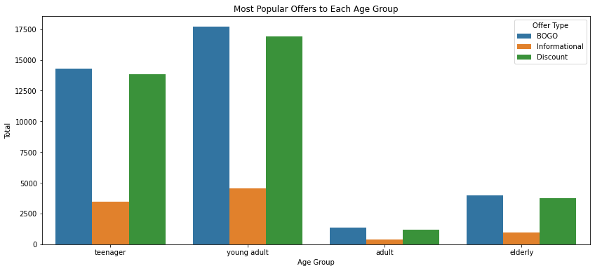

```python
plt.figure(figsize=(14, 6))
g = sns.countplot(x="age_groups", hue="offer_type", data=visualization_df)
plt.title('Most Popular Offers to Each Age Group')
plt.ylabel('Total')
plt.xlabel('Age Group')
xlabels = ['teenager','young adult','adult','elderly']
g.set_xticklabels(xlabels)
plt.xticks(rotation = 0)
plt.legend(title='Offer Type')
plt.show();
```

# which type of offer does each gender like

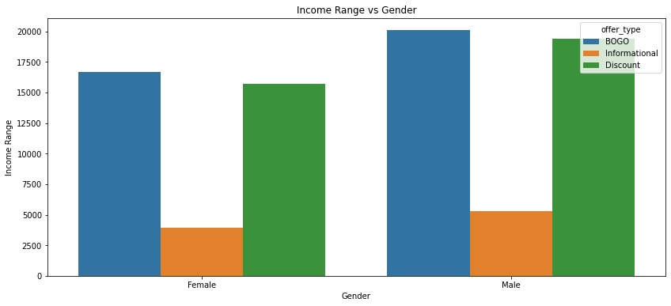

```python
plt.figure(figsize=(14, 6))
g = sns.countplot(x="gender", hue="offer_type", data= visualization_df[visualization_df["gender"]!=3])
plt.title('Income Range vs Gender')
plt.ylabel('Income Range')
xlabels = ['Female', 'Male']
g.set_xticklabels(xlabels)
plt.xlabel('Gender')
plt.xticks(rotation = 0)
plt.show();
```

# which gender is having the highest income range?

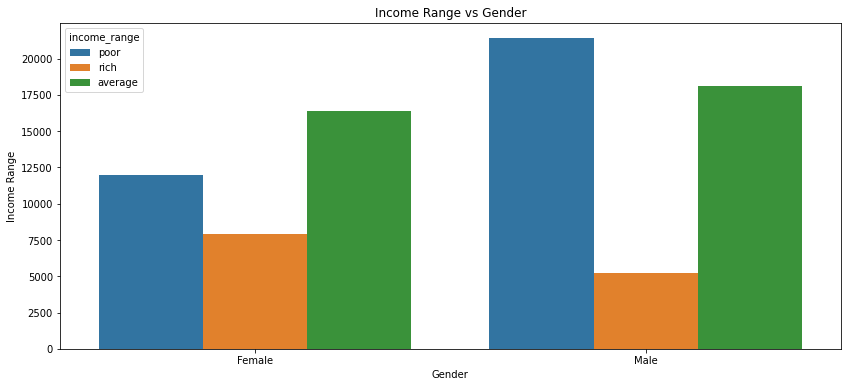

```python
plt.figure(figsize=(14, 6))
g = sns.countplot(x="gender", hue="income_range", data= visualization_df[visualization_df["gender"]!=3])
plt.title('Income Range vs Gender')
plt.ylabel('Income Range')
xlabels = ['Female', 'Male']
g.set_xticklabels(xlabels)
plt.xlabel('Gender')
plt.xticks(rotation = 0)
plt.show();
```

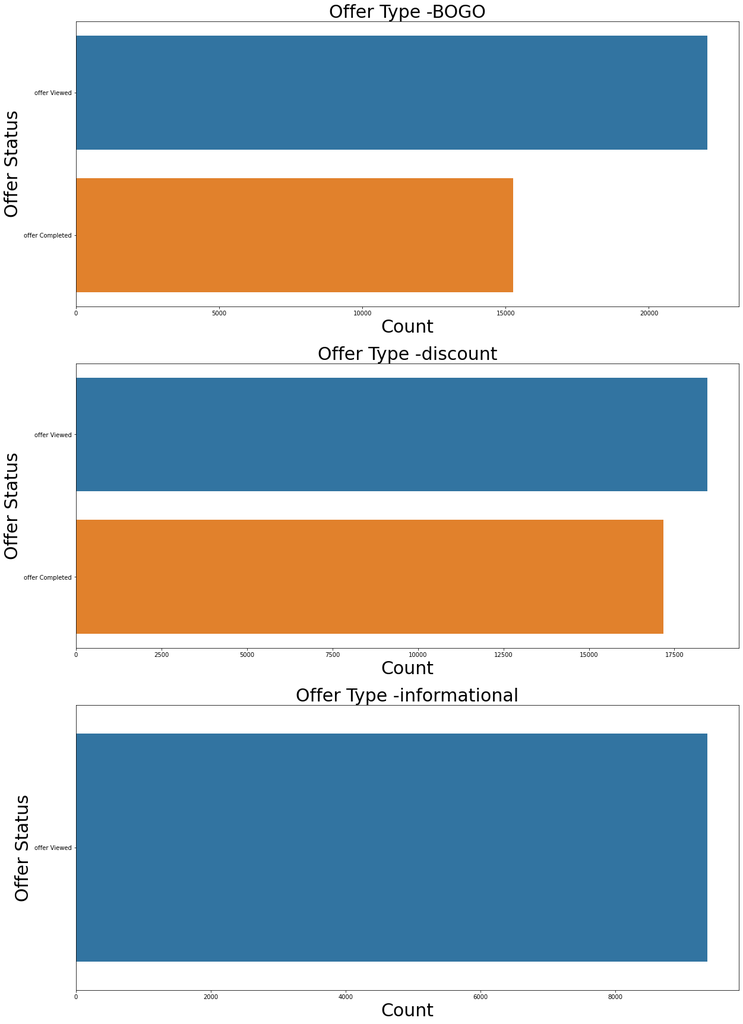

```python
fig, ax =plt.subplots(3,1,figsize=(20,30))
sns.countplot(y=visualization_df[visualization_df.bogo == 1].event,ax=ax[0]);
ax[0].set_title('Offer Type -BOGO',fontsize=30)
ax[0].set_xlabel('Count',fontsize=30)
ax[0].set_ylabel('Offer Status',size=30)
sns.countplot(y=visualization_df[visualization_df.discount == 1].event,ax=ax[1]);
ax[1].set_title('Offer Type -discount',fontsize=30)
ax[1].set_xlabel('Count',fontsize=30)
ax[1].set_ylabel('Offer Status',size=30)
sns.countplot(y=visualization_df[visualization_df.informational == 1].event,ax=ax[2]);
ax[2].set_title('Offer Type -informational',fontsize=30)
ax[2].set_xlabel('Count',fontsize=30)
ax[2].set_ylabel('Offer Status',size=30)
```

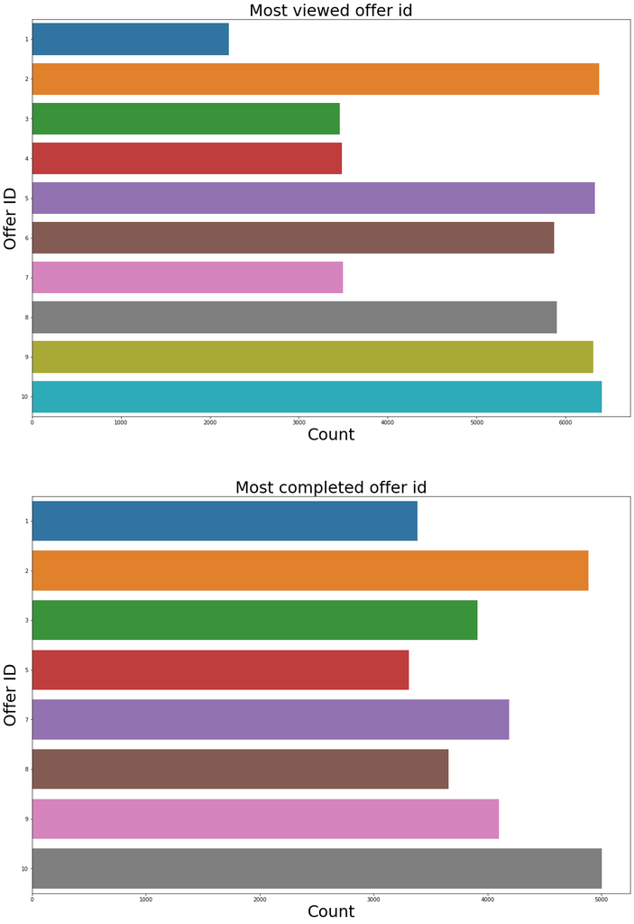

```python
fig, ax =plt.subplots(2,1,figsize=(20,30))
sns.countplot(y=visualization_df[visualization_df.event == 'offer Viewed'].offer_id,ax=ax[0]);
ax[0].set_title('Most viewed offer id',fontsize=30)
ax[0].set_xlabel('Count',fontsize=30)
ax[0].set_ylabel('Offer ID',size=30)
sns.countplot(y=visualization_df[visualization_df.event == 'offer Completed'].offer_id,ax=ax[1]);
ax[1].set_title('Most completed offer id',fontsize=30)
ax[1].set_xlabel('Count',fontsize=30)
ax[1].set_ylabel('Offer ID',size=30)
```

- offer completed ratio is not small

[figure not shown]

```python
plt.figure(figsize=(10,10))
sns.countplot(visualization_df[~visualization_df['offer_type'].isnull()]['offer_type'])
plt.title('Number of Completed Promotion for Type Offer')
plt.ylabel('Number of transactions',fontsize=30)
plt.xlabel('Offer Type',fontsize=30)
plt.xticks(rotation = 50)
plt.show();
```

Bogo and Discount seem the most and they are close to each other with bogo been slightly higher

### Model preparation

```python
df2 = pd.DataFrame(full_list)
```

```python
df2.info()
```

```
<class 'pandas.core.frame.DataFrame'>
Int64Index: 82304 entries, 0 to 91303
Data columns (total 21 columns):
 #   Column          Non-Null Count  Dtype
---  ------          --------------  -----
 0   customer_id     82304 non-null  int64
 1   event           82304 non-null  int64
 2   time_hours      82304 non-null  int64
 3   offer_id        82304 non-null  int64
 4   amount          82304 non-null  int64
 5   reward_x        82304 non-null  int64
 6   reward_y        82304 non-null  int64
 7   difficulty      82304 non-null  int64
 8   duration_hours  82304 non-null  int64
 9   offer_type      82304 non-null  int64
 10  email           82304 non-null  uint8
 11  mobile          82304 non-null  uint8
 12  social          82304 non-null  uint8
 13  web             82304 non-null  uint8
 14  bogo            82304 non-null  uint8
 15  discount        82304 non-null  uint8
 16  informational   82304 non-null  uint8
 17  gender          82304 non-null  float64
 18  age_groups      82304 non-null  float64
 19  income_range    82304 non-null  float64
 20  member_type     82304 non-null  float64
dtypes: float64(4), int64(10), uint8(7)
memory usage: 10.0 MB
```

```python
df2.drop(columns=['customer_id','event','reward_y','bogo','discount','informational','email','mobile','social',"web"],inplace=True)
```

```python
df2.info()
```

```
<class 'pandas.core.frame.DataFrame'>
Int64Index: 82304 entries, 0 to 91303
Data columns (total 11 columns):
 #   Column          Non-Null Count  Dtype
---  ------          --------------  -----
 0   time_hours      82304 non-null  int64
 1   offer_id        82304 non-null  int64
 2   amount          82304 non-null  int64
 3   reward_x        82304 non-null  int64
 4   difficulty      82304 non-null  int64
 5   duration_hours  82304 non-null  int64
 6   offer_type      82304 non-null  int64
 7   gender          82304 non-null  float64
 8   age_groups      82304 non-null  float64
 9   income_range    82304 non-null  float64
 10  member_type     82304 non-null  float64
dtypes: float64(4), int64(7)
memory usage: 7.5 MB
```

```python
Y = full_list['event']
X =df2
```

### Model preparation and evaluation and validation

```python
from sklearn.model_selection import train_test_split, GridSearchCV
from sklearn.linear_model import LogisticRegression
from sklearn.neighbors import KNeighborsClassifier
from sklearn.tree import DecisionTreeClassifier
from sklearn.svm import SVC
from sklearn.ensemble import RandomForestClassifier
from sklearn.naive_bayes import GaussianNB
import sklearn.metrics as metrics
from sklearn.metrics import f1_score
from sklearn.preprocessing import MinMaxScaler
```

```python
X.info()
```

```
<class 'pandas.core.frame.DataFrame'>
Int64Index: 82304 entries, 0 to 91303
Data columns (total 11 columns):
 #   Column          Non-Null Count  Dtype
---  ------          --------------  -----
 0   time_hours      82304 non-null  int64
 1   offer_id        82304 non-null  int64
 2   amount          82304 non-null  int64
 3   reward_x        82304 non-null  int64
 4   difficulty      82304 non-null  int64
 5   duration_hours  82304 non-null  int64
 6   offer_type      82304 non-null  int64
 7   gender          82304 non-null  float64
 8   age_groups      82304 non-null  float64
 9   income_range    82304 non-null  float64
 10  member_type     82304 non-null  float64
dtypes: float64(4), int64(7)
memory usage: 7.5 MB
```

```python
To_scale = MinMaxScaler()
to_normalize = ['time_hours','reward_x','amount','duration_hours' , 'duration_hours','difficulty']

X[to_normalize] = To_scale.fit_transform(X[to_normalize])
X.head()
```

|  | time_hours | offer_id | amount | reward_x | difficulty | duration_hours | offer_type | gender | age_groups | income_range | member_type |
| --- | --- | --- | --- | --- | --- | --- | --- | --- | --- | --- | --- |
| 0 | 0.0 | 9 | 0.0 | 0.0 | 0.25 | 0.285714 | 1 | 2.0 | 4.0 | 1.0 | 1.0 |
| 1 | 0.0 | 6 | 0.0 | 0.0 | 0.00 | 0.000000 | 3 | 3.0 | 3.0 | 1.0 | 1.0 |
| 2 | 0.0 | 5 | 0.0 | 0.0 | 0.50 | 0.285714 | 1 | 1.0 | 4.0 | 1.0 | 2.0 |
| 3 | 0.0 | 8 | 0.0 | 0.0 | 0.50 | 0.571429 | 1 | 1.0 | 1.0 | 1.0 | 2.0 |
| 4 | 0.0 | 6 | 0.0 | 0.0 | 0.00 | 0.000000 | 3 | 2.0 | 3.0 | 1.0 | 3.0 |

```python
X.head()
```

```python
X_train, X_test, y_train, y_test = train_test_split(X, Y, test_size=0.2, random_state=42)
print("Training set has {} samples.".format(X_train.shape[0]))
print("Testing set has {} samples.".format(X_test.shape[0]))
```

```
Training set has 65843 samples.
Testing set has 16461 samples.
```

```python
'''
TP = np.sum(income) # Counting the ones as this is the naive case. Note that 'income' is the 'income_raw' data
encoded to numerical values done in the data preprocessing step.
FP = income.count() - TP # Specific to the naive case

TN = 0 # No predicted negatives in the naive case
FN = 0 # No predicted negatives in the naive case
'''
# TODO: Calculate accuracy, precision and recall
TP = np.sum(Y)
FP =Y.shape[0]-TP
TN =0
FN =0
accuracy = TP/(TP+FP)
recall = TP/(TP+FN)
precision = TP/(TP+FP)
beta = 0.5

# TODO: Calculate F-score using the formula above for beta = 0.5 and correct values for precision and recall.
fscore =  (1+ beta**2) * (precision * recall) / ((beta ** 2 * precision) + recall)

# Print the results
print("Naive Predictor: [Accuracy score: {:.4f}, F-score: {:.4f}]".format(accuracy, fscore))
```

```
Naive Predictor: [Accuracy score: 1.6058, F-score: 1.4323]
```

```python
# TODO: Import two metrics from sklearn - fbeta_score and accuracy_score
from sklearn.metrics import fbeta_score, accuracy_score

def train_predict(learner, sample_size, X_train, y_train, X_test, y_test):
    '''
    inputs:
       - learner: the learning algorithm to be trained and predicted on
       - sample_size: the size of samples (number) to be drawn from training set
       - X_train: features training set
       - y_train: income training set
       - X_test: features testing set
       - y_test: income testing set
    '''

    results = {}

    # TODO: Fit the learner to the training data using slicing with 'sample_size' using .fit(training_features[:], training_labels[:])
    start = time() # Get start time
    learner = learner.fit(X_train[:sample_size],y_train[:sample_size])
    end = time() # Get end time

    # TODO: Calculate the training time
    results['train_time'] = end-start

    # TODO: Get the predictions on the test set(X_test),
    #       then get predictions on the first 300 training samples(X_train) using .predict()
    start = time() # Get start time
    predictions_test = learner.predict(X_test)
    predictions_train = learner.predict(X_train[:300])
    end = time() # Get end time

    # TODO: Calculate the total prediction time
    results['pred_time'] = end-start

    # TODO: Compute accuracy on the first 300 training samples which is y_train[:300]
    results['acc_train'] = accuracy_score(y_train[:300], predictions_train)

    # TODO: Compute accuracy on test set using accuracy_score()
    results['acc_test'] =  accuracy_score(y_test, predictions_test)

    # TODO: Compute F-score on the the first 300 training samples using fbeta_score()
    results['f_train'] = fbeta_score(y_train[:300], predictions_train[:300], beta = 0.5)

    # TODO: Compute F-score on the test set which is y_test
    results['f_test'] = fbeta_score(y_test, predictions_test, beta = 0.5)

    # Success
    print("{} trained on {} samples.".format(learner.__class__.__name__, sample_size))

    # Return the results
    return results
```

# Model evaluation

```python
import visuals as vs
```

```
SVC trained on 658 samples.
SVC trained on 6584 samples.
SVC trained on 65843 samples.
RandomForestClassifier trained on 658 samples.
RandomForestClassifier trained on 6584 samples.
RandomForestClassifier trained on 65843 samples.
AdaBoostClassifier trained on 658 samples.
AdaBoostClassifier trained on 6584 samples.
AdaBoostClassifier trained on 65843 samples.
```

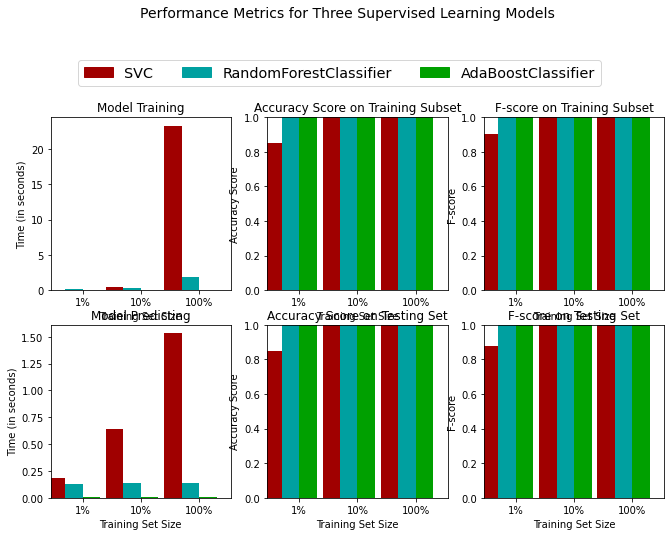

```python
# TODO: Import the three supervised learning models from sklearn
from sklearn.ensemble import RandomForestClassifier
from sklearn import svm
from sklearn.ensemble import AdaBoostClassifier

# TODO: Initialize the three models
clf_A = svm.SVC(random_state = 7)
clf_B = RandomForestClassifier(random_state=543)
clf_C = AdaBoostClassifier(random_state=543)

# TODO: Calculate the number of samples for 1%, 10%, and 100% of the training data
# HINT: samples_100 is the entire training set i.e. len(y_train)
# HINT: samples_10 is 10% of samples_100 (ensure to set the count of the values to be `int` and not `float`)
# HINT: samples_1 is 1% of samples_100 (ensure to set the count of the values to be `int` and not `float`)
samples_100 = len(y_train)
samples_10 = int(samples_100 * 0.1)
samples_1 =  int(samples_100 * 0.01)

# Collect results on the learners
results = {}
for clf in [clf_A, clf_B, clf_C]:
    clf_name = clf.__class__.__name__
    results[clf_name] = {}
    for i, samples in enumerate([samples_1, samples_10, samples_100]):
        results[clf_name][i] = \
        train_predict(clf, samples, X_train, y_train, X_test, y_test)

# Run metrics visualization for the three supervised learning models chosen
vs.evaluate(results, accuracy, fscore)
```

The above figure show the accuracy and f score for the different models and the time required for each model to run. We are able to see that the adaboost model is the best as it reached highest testing and training accuracy with lowest time

# Model Refinment

```python
# TODO: Import 'GridSearchCV', 'make_scorer', and any other necessary libraries
from sklearn.metrics import make_scorer
from sklearn.model_selection import GridSearchCV

# TODO: Initialize the classifier
clf = AdaBoostClassifier(random_state=543)

# TODO: Create the parameters list you wish to tune, using a dictionary if needed.
# HINT: parameters = {'parameter_1': [value1, value2], 'parameter_2': [value1, value2]}
parameters = dict(n_estimators=[250,1000],
                learning_rate=[1,0.001],
                algorithm =['SAMME', 'SAMME.R'])
# TODO: Make an fbeta_score scoring object using make_scorer()
scorer = make_scorer(fbeta_score, beta=0.5)

# TODO: Perform grid search on the classifier using 'scorer' as the scoring method using GridSearchCV()
grid_obj = GridSearchCV(clf, param_grid = parameters,scoring=scorer)

# TODO: Fit the grid search object to the training data and find the optimal parameters using fit()
grid_fit = grid_obj.fit(X_train, y_train)

# Get the estimator
best_clf = grid_fit.best_estimator_

# Make predictions using the unoptimized and model
predictions = (clf.fit(X_train, y_train)).predict(X_test)
best_predictions = best_clf.predict(X_test)

# Report the before-and-afterscores
print("Unoptimized model\n------")
print("Accuracy score on testing data: {:.4f}".format(accuracy_score(y_test, predictions)))
print("F-score on testing data: {:.4f}".format(fbeta_score(y_test, predictions, beta = 0.5)))
print("\nOptimized Model\n------")
print("Final accuracy score on the testing data: {:.4f}".format(accuracy_score(y_test, best_predictions)))
print("Final F-score on the testing data: {:.4f}".format(fbeta_score(y_test, best_predictions, beta = 0.5)))
```

```
Unoptimized model
------
Accuracy score on testing data: 1.0000
F-score on testing data: 1.0000

Optimized Model
------
Final accuracy score on the testing data: 1.0000
Final F-score on the testing data: 1.0000
```

although the results is good, i tried to optimize the model by changing in the model parameters to check if we can achieve better results. As we can see, there is not any diffference between the optimized model and non optimized model.

### Conclusion

We tried in this project to analyze the dataset and build a model that can predict whether a custommer would complete the offer or just check it I had different numerical variables that i had to turn into categorical by splitting the continous data into a ranges with each range has specific categorical name. I did this with the age, salary, events,gender, offer type and the day since being a member. I cleaned the data to remove any null value or duplicatesfrom the dataset. I used 3 diffferent machine learning model to compare and choose which model is the best to accuratly predict if the custommer will complete the offer or not.

# Reflection

I enjoyed this capstone project and it helped me too apply everything i did throughout the nano degree.The most important step in this process is in understanding the data and clearning it

# Improvement

I think we need to try to find a model that can predict which kind of offers to be send to which customer